# part4_image_classification

##### Turning on learning rate

```python
fit_data_list = []
lr_list = [0.1,0.01,0.001,0.0001]
for lr in lr_list:
    print("lr-------------",lr)
    model_lr = nn_model()
    optimizer = SGD(learning_rate=lr)
    model_lr.compile(optimizer = optimizer, loss = 'categorical_crossentropy', metrics = ['accuracy'])
    fit_data = model_lr.fit(X_train, y_train, validation_data=(X_val,y_val),batch_size = 32, epochs = 10, verbose = 1)
    fit_data_list.append(fit_data)
    print("-------------------")
```

```
lr------------- 0.1
-------------------
lr------------- 0.01
-------------------
lr------------- 0.001
-------------------
lr------------- 0.0001
-------------------
```

```python
fit_data_list
```

```
[<tensorflow.python.keras.callbacks.History at 0x276473b7df0>,
 <tensorflow.python.keras.callbacks.History at 0x27647ff1c40>,
 <tensorflow.python.keras.callbacks.History at 0x27649850c10>,
 <tensorflow.python.keras.callbacks.History at 0x2764ae8e640>]
```

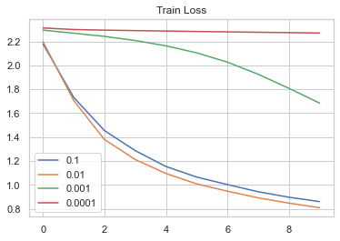

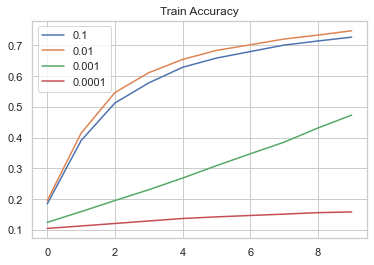

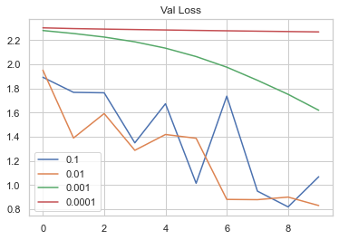

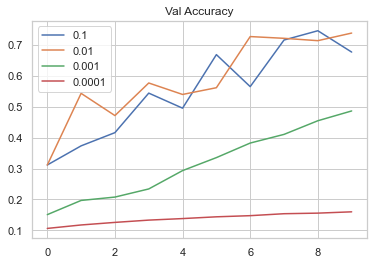

```python
# plot loss during training
# plot loss during training
plt.subplot(111)
plt.title('Train Loss')

index = 0
for x in fit_data_list:
    plt.plot(x.history['loss'],label=lr_list[index])
    index = index +1
plt.legend()
plt.show()

# plot loss during training
plt.subplot(111)
plt.title('Train Accuracy')
index = 0
for x in fit_data_list:
    plt.plot(x.history['accuracy'],label=lr_list[index])
    index = index +1
plt.legend()
plt.show()





plt.subplot(111)
plt.title('Val Loss')

index = 0
for x in fit_data_list:
    plt.plot(x.history['val_loss'],label=lr_list[index])
    index = index +1
plt.legend()
plt.show()

# plot loss during training
plt.subplot(111)
plt.title('Val Accuracy')
index = 0
for x in fit_data_list:
    plt.plot(x.history['val_accuracy'],label=lr_list[index])
    index = index +1
plt.legend()
```

Observation - learning rate of 0.01 has high accuracy with a decrease on loss. Good to try for more epochs to check the same

##### Adding momentum + more epochs

```python
# 100 - epochs
model_momentum = nn_model()
optimizer = SGD(learning_rate=0.01,momentum=0.9)
model_momentum.compile(optimizer = optimizer, loss = 'categorical_crossentropy', metrics = ['accuracy'])
fit_data = model_momentum.fit(X_train, y_train, validation_data=(X_val,y_val),batch_size = 32, epochs = 100, verbose = 1)
```

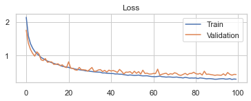

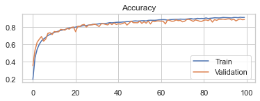

```python
# plot loss during training
plt.subplot(211)
plt.title('Loss')
plt.plot(fit_data.history['loss'],label="Train")
plt.plot(fit_data.history['val_loss'],label="Validation")
plt.legend()
plt.show()

# plot loss during training
plt.subplot(211)
plt.title('Accuracy')
plt.plot(fit_data.history['accuracy'],label="Train")
plt.plot(fit_data.history['val_accuracy'],label="Validation")

plt.legend()
plt.show()
```

Observation

- This is no major variation bwt the train and validation. Check how model perform on Test data

```python
test_results = model_momentum.evaluate(X_test,y_test)
test_results
```

```
[0.8053175210952759, 0.8155555725097656]
```

Observation :

Train accuracy - 91% ; Test accuracy - 81% - Overfit Next step - to check with "Weight Initialization" and adding BatchNormalization layer

##### Turning on Weight Initialization

```python
fit_data_list = []
kernel_initializer_list = ['uniform','normal', 'zero', 'he_normal', 'he_uniform']
for kernel_initializer in kernel_initializer_list:
    print("kernel_initializer-------------",kernel_initializer)
    model_weight = nn_model(kernel_initializer)
    optimizer = SGD(learning_rate=0.01,momentum=0.9)
    model_weight.compile(optimizer = optimizer, loss = 'categorical_crossentropy', metrics = ['accuracy'])
    fit_data = model_weight.fit(X_train, y_train, validation_data=(X_val,y_val),batch_size = 32, epochs = 10, verbose = 1)
    fit_data_list.append(fit_data)
    print("-------------------")
```

```
kernel_initializer------------- uniform
-------------------
kernel_initializer------------- normal
-------------------
kernel_initializer------------- zero
-------------------
kernel_initializer------------- he_normal
-------------------
kernel_initializer------------- he_uniform
-------------------
```

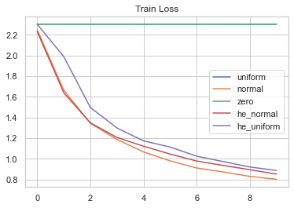

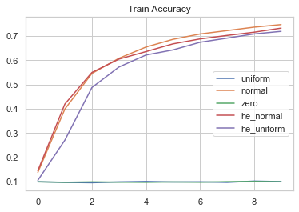

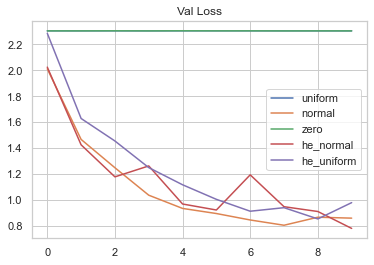

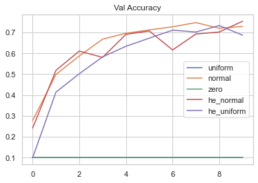

```python
# plot loss during training
plt.subplot(111)
plt.title('Train Loss')
index = 0
for x in fit_data_list:
    plt.plot(x.history['loss'],label=kernel_initializer_list[index])
    index = index +1
plt.legend()
plt.show()


# plot loss during training
plt.subplot(111)
plt.title('Train Accuracy')
index = 0
for x in fit_data_list:
    plt.plot(x.history['accuracy'],label=kernel_initializer_list[index])
    index = index +1
plt.legend()
plt.show()



# plot loss during training
plt.subplot(111)
plt.title('Val Loss')
index = 0
for x in fit_data_list:
    plt.plot(x.history['val_loss'],label=kernel_initializer_list[index])
    index = index +1
plt.legend()
plt.show()


# plot loss during training
plt.subplot(111)
plt.title('Val Accuracy')
index = 0
for x in fit_data_list:
    plt.plot(x.history['val_accuracy'],label=kernel_initializer_list[index])
    index = index +1
plt.legend()
plt.show()
```

Observation - weight initialization method of "normal" and "he_normal" is good